# Insurance_Claim_Sythetic_Data

#### Problem Statement:

The dataset provided is a synthetic dataset generated using a CTGAN based on a original dataset. The original dataset was used to predict the amount of an insurance claim. The features provided in this synthetic dataset have some similarities and properties relating to real-world features.

Objective for this dataset is also to predict an amount of insurance claim based on the features provided.

#### Importing Revelant Libraries

```python
import pandas as pd
import numpy as np
import matplotlib.pyplot as plt
import seaborn as sns
sns.set(style='darkgrid')
from sklearn.preprocessing import LabelEncoder
from sklearn.feature_selection import mutual_info_regression
import ppscore as pps
from sklearn.cluster import KMeans
from sklearn.preprocessing import OneHotEncoder
from sklearn.model_selection import train_test_split
from sklearn.preprocessing import StandardScaler
from xgboost import XGBRegressor
from sklearn.ensemble import RandomForestClassifier
from sklearn.metrics import mean_absolute_error
```

#### Loading Training and Test datasets

```python
df_train = pd.read_csv('train.csv')
df_test = pd.read_csv('test.csv')

#Merging both df's for future feature tarnsformations
df_all = df_train.append(df_test)
```

#### Dataset Info

```python
print(df_train.shape)
print(df_test.shape)
print(df_all.shape)
```

```
(300000, 26)
(200000, 25)
(500000, 26)
```

```python
df_all.columns
```

```
Index(['id', 'cat0', 'cat1', 'cat2', 'cat3', 'cat4', 'cat5', 'cat6', 'cat7',
       'cat8', 'cat9', 'cont0', 'cont1', 'cont2', 'cont3', 'cont4', 'cont5',
       'cont6', 'cont7', 'cont8', 'cont9', 'cont10', 'cont11', 'cont12',
       'cont13', 'target'],
      dtype='object')
```

```python
#Missing values in all set
#the missing target values are for the test set
df_all.isnull().sum()
```

```
id             0
cat0           0
cat1           0
cat2           0
cat3           0
cat4           0
cat5           0
cat6           0
cat7           0
cat8           0
cat9           0
cont0          0
cont1          0
cont2          0
cont3          0
cont4          0
cont5          0
cont6          0
cont7          0
cont8          0
cont9          0
cont10         0
cont11         0
cont12         0
cont13         0
target    200000
dtype: int64
```

```python
df_all.info()
```

```
<class 'pandas.core.frame.DataFrame'>
Int64Index: 500000 entries, 0 to 199999
Data columns (total 26 columns):
 #   Column  Non-Null Count   Dtype
---  ------  --------------   -----
 0   id      500000 non-null  int64
 1   cat0    500000 non-null  object
 2   cat1    500000 non-null  object
 3   cat2    500000 non-null  object
 4   cat3    500000 non-null  object
 5   cat4    500000 non-null  object
 6   cat5    500000 non-null  object
 7   cat6    500000 non-null  object
 8   cat7    500000 non-null  object
 9   cat8    500000 non-null  object
```

[output cut: 18 more lines]

```python
df_train.describe()
```

|  | id | cont0 | cont1 | cont2 | cont3 | cont4 | cont5 | cont6 | cont7 | cont8 | cont9 | cont10 | cont11 | cont12 | cont13 | target |
| --- | --- | --- | --- | --- | --- | --- | --- | --- | --- | --- | --- | --- | --- | --- | --- | --- |
| count | 300000.000000 | 300000.000000 | 300000.000000 | 300000.000000 | 300000.000000 | 300000.000000 | 300000.000000 | 300000.000000 | 300000.000000 | 300000.000000 | 300000.000000 | 300000.000000 | 300000.000000 | 300000.000000 | 300000.000000 | 300000.000000 |
| mean | 250018.576947 | 0.524634 | 0.506649 | 0.444115 | 0.446214 | 0.455471 | 0.508337 | 0.478345 | 0.455904 | 0.459321 | 0.526899 | 0.504943 | 0.529938 | 0.524549 | 0.503349 | 7.456260 |
| std | 144450.150010 | 0.204875 | 0.235269 | 0.200089 | 0.238669 | 0.200695 | 0.231612 | 0.192432 | 0.204493 | 0.220642 | 0.204025 | 0.201549 | 0.230860 | 0.220892 | 0.225218 | 0.887295 |
| min | 1.000000 | -0.093505 | -0.055105 | -0.060274 | 0.134760 | 0.189216 | -0.087247 | 0.043953 | 0.208703 | 0.004041 | 0.073040 | 0.059644 | 0.064161 | -0.005600 | 0.158121 | 0.000000 |
| 25% | 124772.500000 | 0.370451 | 0.352307 | 0.314121 | 0.214572 | 0.279853 | 0.338747 | 0.339896 | 0.278041 | 0.308655 | 0.361957 | 0.338898 | 0.316662 | 0.332143 | 0.291289 | 6.798341 |
| 50% | 250002.500000 | 0.492208 | 0.615156 | 0.457271 | 0.377823 | 0.411351 | 0.441384 | 0.410090 | 0.360736 | 0.425801 | 0.488867 | 0.519855 | 0.558827 | 0.407365 | 0.433909 | 7.496503 |
| 75% | 375226.500000 | 0.654793 | 0.688150 | 0.554835 | 0.719758 | 0.621808 | 0.709515 | 0.604246 | 0.639388 | 0.541525 | 0.752765 | 0.672809 | 0.720381 | 0.732431 | 0.730870 | 8.161166 |
| max | 499999.000000 | 1.052666 | 0.851746 | 1.017689 | 1.006469 | 0.994050 | 1.044433 | 1.093312 | 1.036541 | 1.014156 | 0.972091 | 1.029773 | 1.038049 | 0.961370 | 0.873579 | 10.309208 |

```python
df_test.describe()
```

|  | id | cont0 | cont1 | cont2 | cont3 | cont4 | cont5 | cont6 | cont7 | cont8 | cont9 | cont10 | cont11 | cont12 | cont13 |
| --- | --- | --- | --- | --- | --- | --- | --- | --- | --- | --- | --- | --- | --- | --- | --- |
| count | 200000.000000 | 200000.000000 | 200000.000000 | 200000.000000 | 200000.000000 | 200000.000000 | 200000.000000 | 200000.000000 | 200000.000000 | 200000.000000 | 200000.000000 | 200000.000000 | 200000.000000 | 200000.000000 | 200000.000000 |
| mean | 249970.884580 | 0.524644 | 0.505625 | 0.443344 | 0.445698 | 0.454953 | 0.508761 | 0.478229 | 0.455766 | 0.459130 | 0.526956 | 0.505695 | 0.529122 | 0.523904 | 0.503693 |
| std | 144169.245904 | 0.204638 | 0.235055 | 0.199677 | 0.238721 | 0.200209 | 0.231695 | 0.192374 | 0.204341 | 0.220842 | 0.203714 | 0.202186 | 0.230578 | 0.220578 | 0.225246 |
| min | 0.000000 | -0.091359 | -0.048022 | -0.056000 | 0.135861 | 0.190009 | -0.057938 | 0.037044 | 0.210527 | 0.000756 | 0.082659 | 0.061741 | 0.070391 | 0.012898 | 0.156231 |
| 25% | 125316.750000 | 0.370482 | 0.351918 | 0.313682 | 0.214368 | 0.279851 | 0.339745 | 0.340300 | 0.277950 | 0.308703 | 0.361895 | 0.338309 | 0.317015 | 0.332291 | 0.291208 |
| 50% | 249997.000000 | 0.492627 | 0.614886 | 0.456888 | 0.376929 | 0.411298 | 0.441504 | 0.410049 | 0.360921 | 0.425561 | 0.487917 | 0.522787 | 0.555936 | 0.404961 | 0.437237 |
| 75% | 374649.750000 | 0.654624 | 0.686965 | 0.553847 | 0.719421 | 0.615436 | 0.710453 | 0.603509 | 0.639641 | 0.541239 | 0.752074 | 0.674581 | 0.719863 | 0.730765 | 0.730989 |
| max | 499995.000000 | 1.047206 | 0.845711 | 1.021539 | 1.003975 | 0.981507 | 1.041597 | 1.089515 | 1.047141 | 1.014324 | 0.961880 | 1.031986 | 1.039108 | 0.966387 | 0.879754 |

```python
df_train.describe(include='object')
```

|  | cat0 | cat1 | cat2 | cat3 | cat4 | cat5 | cat6 | cat7 | cat8 | cat9 |
| --- | --- | --- | --- | --- | --- | --- | --- | --- | --- | --- |
| count | 300000 | 300000 | 300000 | 300000 | 300000 | 300000 | 300000 | 300000 | 300000 | 300000 |
| unique | 2 | 2 | 2 | 4 | 4 | 4 | 8 | 8 | 7 | 15 |
| top | A | A | A | C | B | B | A | E | C | F |
| freq | 281471 | 162678 | 276551 | 183752 | 297373 | 149208 | 292643 | 267631 | 121054 | 107281 |

```python
df_test.describe(include='object')
```

|  | cat0 | cat1 | cat2 | cat3 | cat4 | cat5 | cat6 | cat7 | cat8 | cat9 |
| --- | --- | --- | --- | --- | --- | --- | --- | --- | --- | --- |
| count | 200000 | 200000 | 200000 | 200000 | 200000 | 200000 | 200000 | 200000 | 200000 | 200000 |
| unique | 2 | 2 | 2 | 4 | 4 | 4 | 7 | 8 | 7 | 15 |
| top | A | A | A | C | B | B | A | E | C | F |
| freq | 187700 | 108047 | 184259 | 123185 | 198283 | 99662 | 195157 | 178335 | 80741 | 71623 |

```python
df_all.head(5)
```

|  | id | cat0 | cat1 | cat2 | cat3 | cat4 | cat5 | cat6 | cat7 | cat8 | ... | cont5 | cont6 | cont7 | cont8 | cont9 | cont10 | cont11 | cont12 | cont13 | target |
| --- | --- | --- | --- | --- | --- | --- | --- | --- | --- | --- | --- | --- | --- | --- | --- | --- | --- | --- | --- | --- | --- |
| 0 | 1 | A | B | A | A | B | D | A | E | C | ... | 0.881122 | 0.421650 | 0.741413 | 0.895799 | 0.802461 | 0.724417 | 0.701915 | 0.877618 | 0.719903 | 6.994023 |
| 1 | 2 | B | A | A | A | B | B | A | E | A | ... | 0.440011 | 0.346230 | 0.278495 | 0.593413 | 0.546056 | 0.613252 | 0.741289 | 0.326679 | 0.808464 | 8.071256 |
| 2 | 3 | A | A | A | C | B | D | A | B | C | ... | 0.914155 | 0.369602 | 0.832564 | 0.865620 | 0.825251 | 0.264104 | 0.695561 | 0.869133 | 0.828352 | 5.760456 |
| 3 | 4 | A | A | A | C | B | D | A | E | G | ... | 0.934138 | 0.578930 | 0.407313 | 0.868099 | 0.794402 | 0.494269 | 0.698125 | 0.809799 | 0.614766 | 7.806457 |
| 4 | 6 | A | B | A | A | B | B | A | E | C | ... | 0.382600 | 0.705940 | 0.325193 | 0.440967 | 0.462146 | 0.724447 | 0.683073 | 0.343457 | 0.297743 | 6.868974 |

5 rows × 26 columns

###### Observation:

1. Training set has 300000 data points with 26 features, test having 200000 data points with 25 features. The extra feature for training set being the target/insurance claim.
2. Both the training and test dataset have 10 categorical features, 14 continous/numerical features and id.
3. Zero missing values present for both the datasets.
4. Feature distribution for both the sets is fairly similar on first look, the only difference being the presence of a extra unique value in the training set for 'cat6'.

#### Exploratory Data Anlysis

```python
#Intial thoughts: The dataset does not have any clear insights just from looking at the feature names, for example a catx
#feature could be nominal or ordinal but no such variable description is provided here and the fature name itself does not
#indicate anything.
#Considering the dataset is based on insurance claim, a categorical feature based on damage_done or damage_severity would
#have had more weightage over a feature that is based on city_of_claim or incident_location
```

#### Categorical Feature Analysis

#### Density Plots for Cat0,Cat1,Cat2

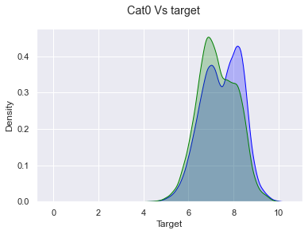

```python
fig,ax =plt.subplots()
sns.kdeplot(df_train[df_train.cat0 == 'A']['target'],shade=True,color="blue",label="Cat0-A",ax=ax)
sns.kdeplot(df_train[df_train.cat0 == 'B']['target'],shade=True,color="green",label="Cat0-B",ax=ax)
ax.set_xlabel("Target")
ax.set_ylabel("Density")

fig.suptitle("Cat0 Vs target ");
```

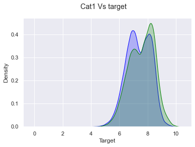

```python
fig,ax =plt.subplots()
sns.kdeplot(df_train[df_train.cat1 == 'A']['target'],shade=True,color="blue",label="Cat1-A",ax=ax)
sns.kdeplot(df_train[df_train.cat1 == 'B']['target'],shade=True,color="green",label="Cat1-B",ax=ax)
ax.set_xlabel("Target")
ax.set_ylabel("Density")

fig.suptitle("Cat1 Vs target ");
```

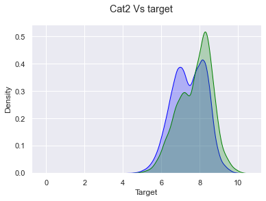

```python
fig,ax =plt.subplots()
sns.kdeplot(df_train[df_train.cat2 == 'A']['target'],shade=True,color="blue",label="Cat1-A",ax=ax)
sns.kdeplot(df_train[df_train.cat2 == 'B']['target'],shade=True,color="green",label="Cat1-B",ax=ax)
ax.set_xlabel("Target")
ax.set_ylabel("Density")

fig.suptitle("Cat2 Vs target ");
```

```python
cat = ['cat0','cat1','cat2','cat3','cat4','cat5','cat6','cat7','cat8','cat9']
```

#### Count Plots for Categorical Features

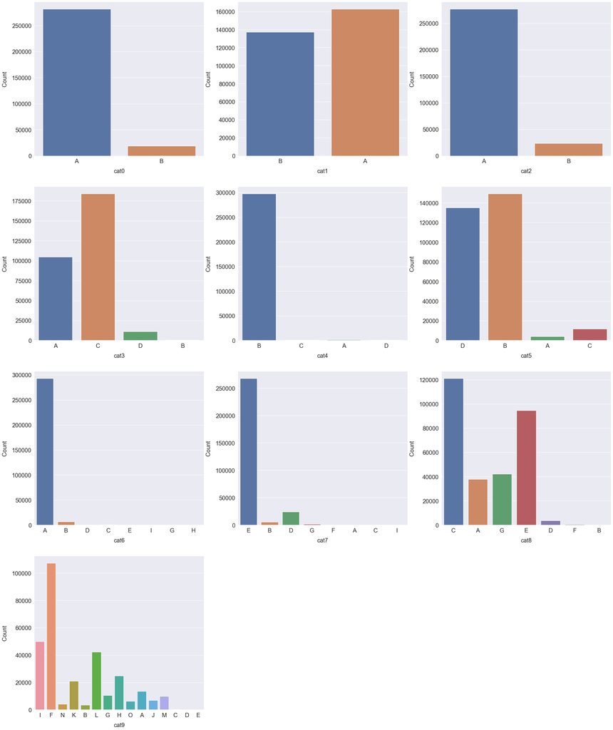

```python
#plt.figure(figsize=(6,6))

#plt.subplot(131)
#plt.boxplot(x=df_train.cat0,data=df_train['target'])
#sns.catplot(x='cat0',y='target',data=df_train,kind='box')
#plt.subplot(132)
#sns.catplot(x='cat1',y='target',data=df_train,kind='box')

fig, axs = plt.subplots(ncols=4, nrows=3, figsize=(20, 30))
plt.subplots_adjust(right=1.5, top=1.25)

for i, feature in enumerate(cat, 1):
    plt.subplot(4, 3, i)
    sns.countplot(x=feature, data=df_train)

    plt.xlabel('{}'.format(feature), size=20, labelpad=15)
    plt.ylabel('Count', size=20, labelpad=15)
    plt.tick_params(axis='x', labelsize=20)
    plt.tick_params(axis='y', labelsize=20)

    #plt.legend(['Not Survived', 'Survived'], loc='upper center', prop={'size': 18})
    #plt.title('Count of Categorical Variables in {} Feature'.format(feature), size=20, y=1.05)

plt.show()
```

#### Striplots for Distribution of Categorical Features VS Target

##### Note: Plots like catplot are not compatible with subplot and hence cannot be plotted in a grid, a good alternative is striplot. (Still need to figure out how to plot on the second row of a subplot grid with striplot, using two statement here for the meanwhile)

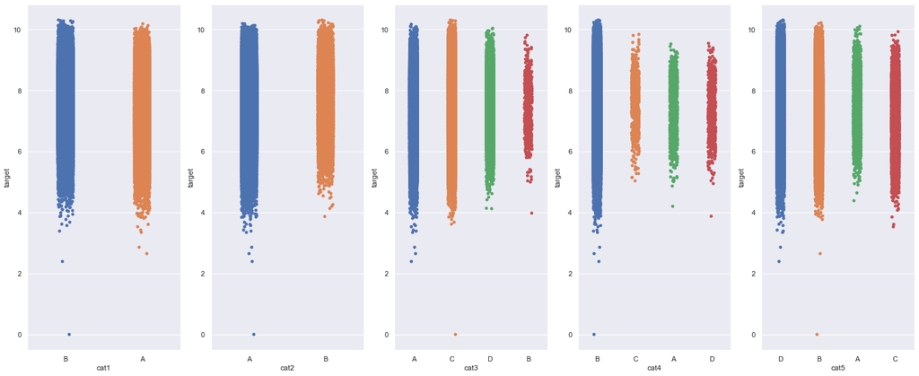

```python
fig, axs = plt.subplots (1, 5, figsize=(25, 10))

sns.stripplot(x='cat1', y='target', data=df_train, ax=axs[0])
sns.stripplot(x='cat2', y='target', data=df_train, ax=axs[1])
sns.stripplot(x='cat3', y='target', data=df_train, ax=axs[2])
sns.stripplot(x='cat4', y='target', data=df_train, ax=axs[3])
sns.stripplot(x='cat5', y='target', data=df_train, ax=axs[4])
```

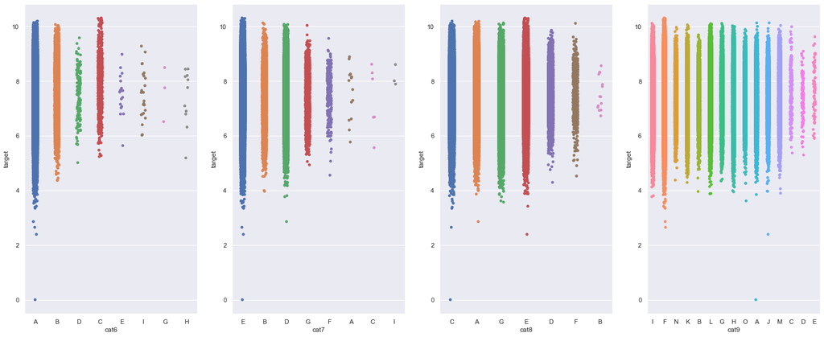

```python
fig, axs = plt.subplots (1, 4, figsize=(25, 10))

sns.stripplot(x='cat6', y='target', data=df_train, ax=axs[0])
sns.stripplot(x='cat7', y='target', data=df_train, ax=axs[1])
sns.stripplot(x='cat8', y='target', data=df_train, ax=axs[2])
sns.stripplot(x='cat9', y='target', data=df_train, ax=axs[3])
```

#### Individual Boxplots for Distribution of Categorical Features VS Target

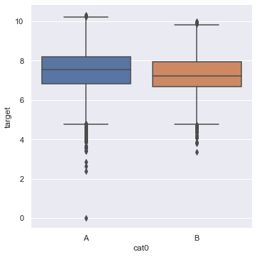

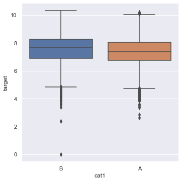

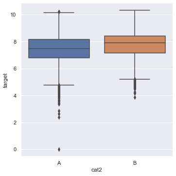

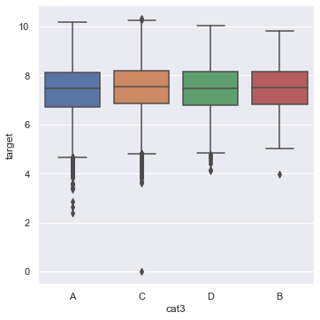

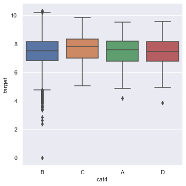

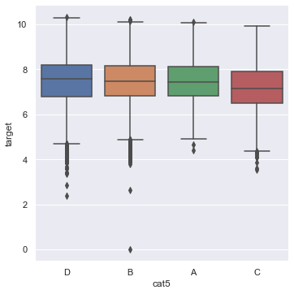

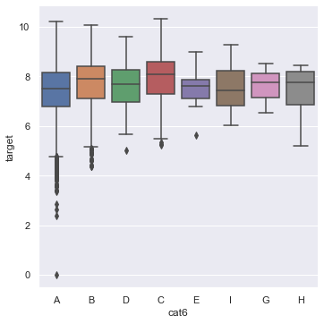

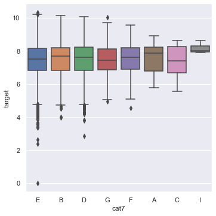

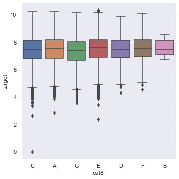

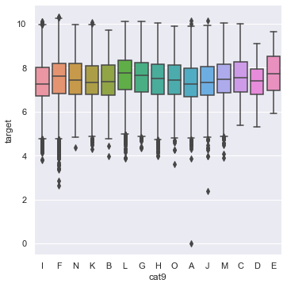

```python
#Enumerate allows to itterate over a list
#Boxplot
for i,feature in enumerate(cat):
    sns.catplot(x=cat[i],y='target',data=df_train,kind='box')
plt.show()
```

#### Histograms for Training and Test Set Categorical Features, same as count plot above

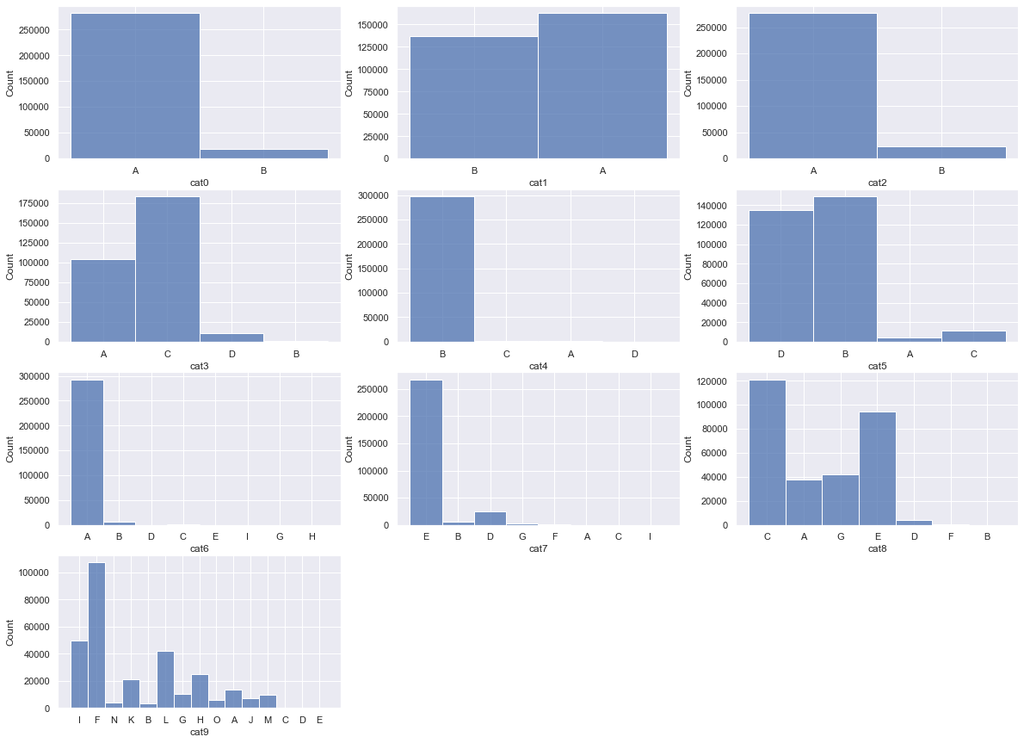

```python
plt.figure(figsize=(20,15))
for i,feature in enumerate(cat):
    plt.subplot(4,3,i+1)
    sns.histplot(df_train[feature])
plt.show()
```

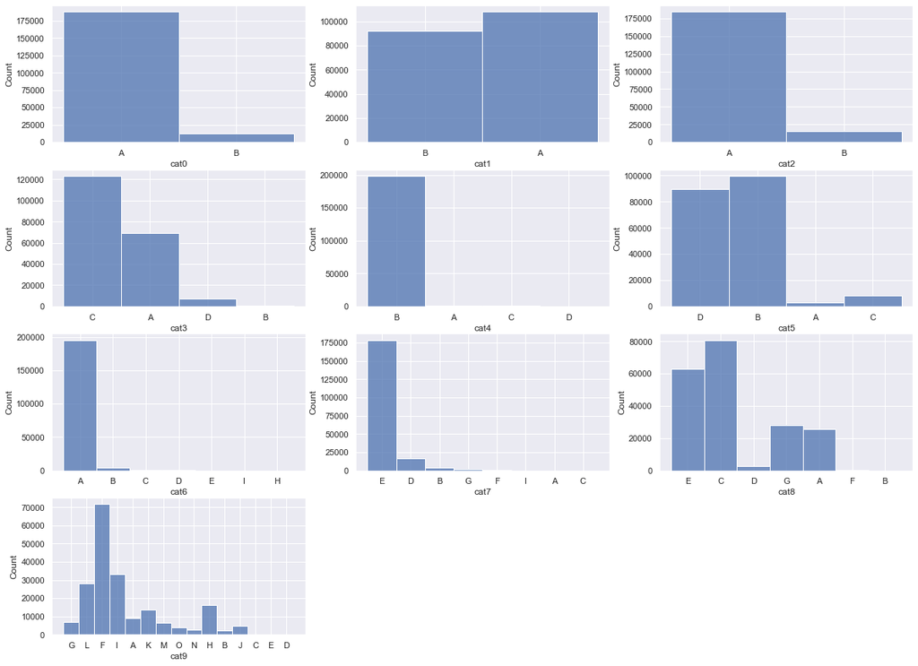

```python
plt.figure(figsize=(20,15))
for i,feature in enumerate(cat):
    plt.subplot(4,3,i+1)
    sns.histplot(df_test[feature])
plt.show()
```

##### Overall Observation:

1. Target Distribution amongst categorical feature categories seems farily equal
2. A lot of categorical features are dominated by a single category. Example: cat0, cat2, cat4, cat6
3. Assumption made: All of these categorical features seem to be nominal
4. Later on in the mdoelling stage we can try dropping a few features mentioned in point no.2 and see any changes in accuracy
5. Will encode these features using One Hot Encoder or get_dummies, under the assumption of point no.3

#### Continous/Numerical Variables

```python
continous = ['cont0','cont1','cont2','cont3','cont4','cont5','cont6','cont7','cont8','cont9','cont10','cont11','cont12','cont13']
```

```python
#All the continous features have a similar mean and variance, so there does not seem to be a need for standardisation.
```

#### Scatter Plots: Contnous variables VS Target

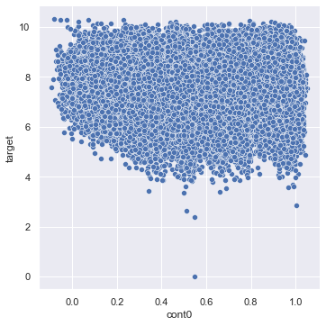

```python
sns.relplot(x='cont0',y='target',data=df_train)
```

#### Just as the scatter plot for cont0 vs target idnicates, there does not seem to be a strong linea relationship between any continous variable and target , plots for the other cont variables are not included here

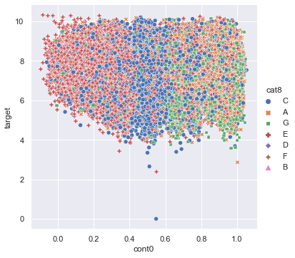

```python
sns.relplot(x='cont0',y='target',data=df_train,hue='cat8',style='cat8')
```

##### Cat8-E is heavily concentrated towards a low cont0 value

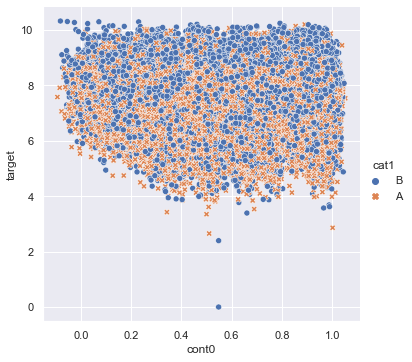

```python
sns.relplot(x='cont0',y='target',data=df_train,hue='cat1',style='cat1')
```

##### Cont0 values with Cat1 category B have a higher Target value

#### Some relational information is present in these scatter plots when the categorical variables are selected as hues, prominent pairs are cat8,cont0 ; cat1,cont0. We will later try finding out mutual information and feature engineering to see if any such information is present and would be usefull to the model. Same process can be tried out with different cont variables.

```python
# A few more scatter plots
```

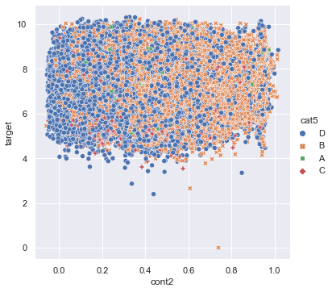

```python
sns.relplot(x='cont2',y='target',data=df_train,hue='cat5',style='cat5')
```

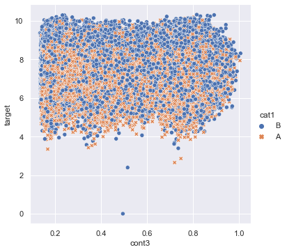

```python
sns.relplot(x='cont3',y='target',data=df_train,hue='cat1',style='cat1')
```

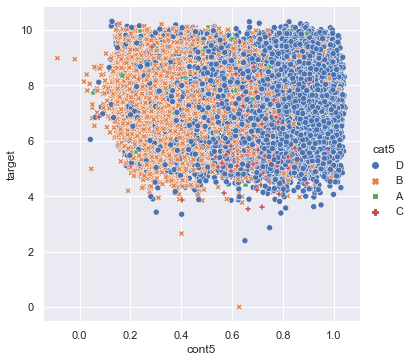

```python
sns.relplot(x='cont5',y='target',data=df_train,hue='cat5',style='cat5')
```

##### Observations:

1. Cat5 is majorly populated by category D & B , on scatter plots for conitnous variables both these categories show a relation where they are concentarted on either the lower value of the cont variable and the second one is concentrated on the higher value of the cont variable or vice versa.
2. Cat 1 shows a similar relationship with all the cont variables, category A is related to lower target values

#### Histograms for Continous Variables

```python
#Training Set
```

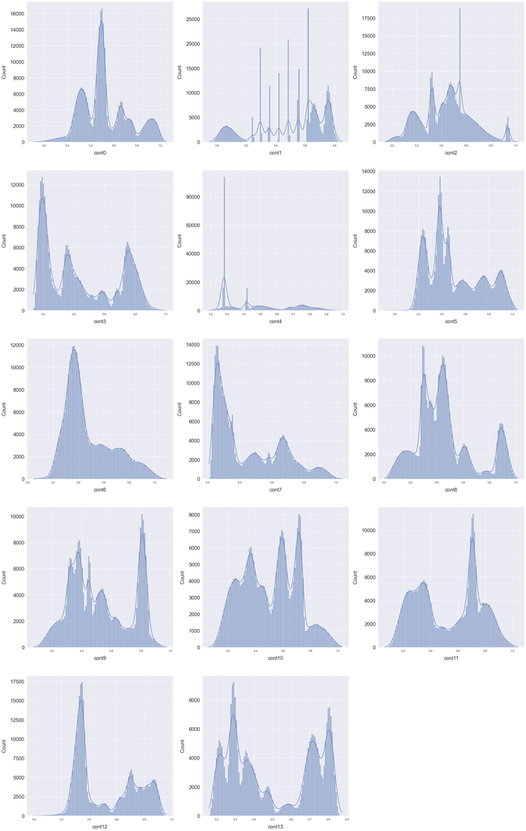

```python
fig, axs = plt.subplots(ncols=5, nrows=4, figsize=(20, 40))
plt.subplots_adjust(right=1.5, top=1.25)

for i, feature in enumerate(continous, 1):
    plt.subplot(5, 3, i)
    sns.histplot(df_train[feature],kde=True,bins=100)

    plt.xlabel('{}'.format(feature), size=20, labelpad=15)
    plt.ylabel('Count', size=20, labelpad=15)
    #plt.tick_params(axis='x', labelsize=20)
    plt.tick_params(axis='y', labelsize=20)

plt.show()
```

```python
#Test Set
```

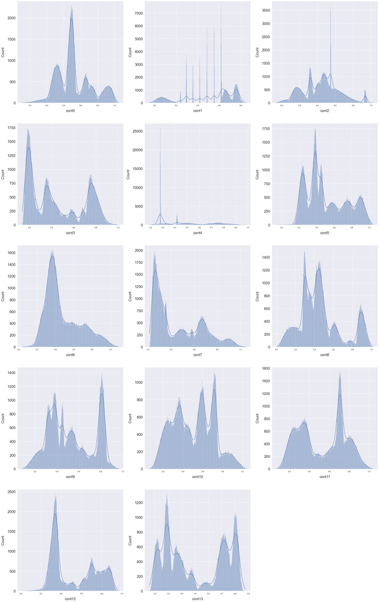

```python
fig, axs = plt.subplots(ncols=5, nrows=4, figsize=(20, 40))
plt.subplots_adjust(right=1.5, top=1.25)

for i, feature in enumerate(continous, 1):
    plt.subplot(5, 3, i)
    sns.histplot(df_test[feature],kde=True,bins=500)

    plt.xlabel('{}'.format(feature), size=20, labelpad=15)
    plt.ylabel('Count', size=20, labelpad=15)
    #plt.tick_params(axis='x', labelsize=20)
    plt.tick_params(axis='y', labelsize=20)

plt.show()
```

##### Observation:

1. Some of the continous variables have a similar bimodial distribution, a few of them have a single or more than 2 peaks but dual peak intensities are very clearly present, these could also be two unimodal distributions(the dataset could be a mergered dataset)
2. cont1 has a suprising distribution, part of it is similar to a categorical variable distribution.
3. Note: read up about qunatile regression, could help in dealing with bimodial distributions
4. Note: https://scikit-learn.org/stable/auto_examples/preprocessing/plot_map_data_to_normal.html ; converting bimodial distributions to normal.
5. Feature scaling will be done later at testing stage.

#### Distribution of the Target

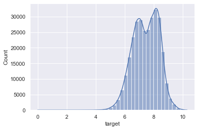

```python
sns.histplot(df_train.target,kde=True,bins=40)
```

#### Correlation Heatmap

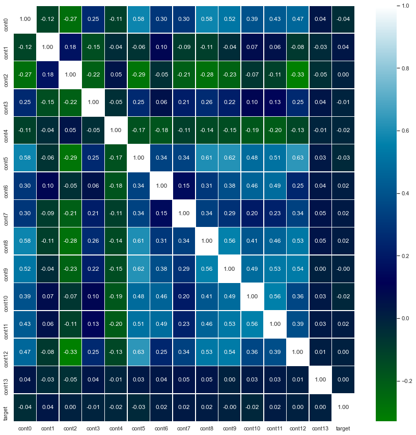

```python
plt.figure(figsize=(15,15))
sns.heatmap(df_train.drop('id',axis=1).corr(),annot=True,fmt=".2f",linewidth=.5, cmap='ocean')
```

#### Mutual Information

```python
#Mutual information will give us relationships between targets and the features
#It detects relationships other than liner relationships as well so we can see if any feature has any correlation with
#the target as in terms of linear relationship there is none present.
#Note: MI can not detect interactions between features, it is univariate metric
```

```python
X = df_train.drop('id',axis=1).copy()
y = X.pop('target')
```

```python
"""The scikit-learn algorithm for MI treats discrete features differently from continuous features. Consequently, you need to tell it which are which. As a rule of thumb, anything that must have a float dtype is not discrete. Categoricals (object or categorial dtype) can be treated as discrete by giving them a label encoding. """
```

[output not shown]

```python
#Label Encoding for categoricals

le = LabelEncoder()
for feature in cat:
    X[feature] = le.fit_transform(X[feature])
```

```python
discrete_features = X.dtypes == int #Double check this before implimentation
```

```python
def mi_scores(X,y,discrete_features):
    mi = mutual_info_regression(X,y,discrete_features=discrete_features)
    mi = pd.Series(mi, name="MI Scores",index = X.columns)
    mi = mi.sort_values(ascending=False)
    return mi
```

```python
mi = mi_scores(X,y,discrete_features)
```

```python
mi[::3]
```

```
cont8     0.012832
cat9      0.011265
cont12    0.007277
cont3     0.006201
cat8      0.004767
cont7     0.004028
cat6      0.002373
cont2     0.000986
Name: MI Scores, dtype: float64
```

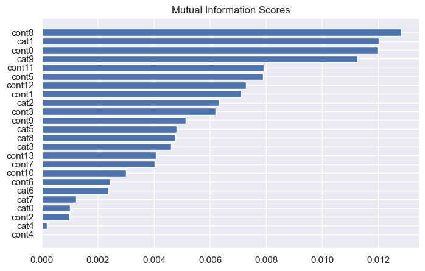

```python
#plotting the mi_scores

plt.figure(dpi=100,figsize=(8,5))
mi=mi.sort_values(ascending=True)
width = np.arange(len(mi))
ticks = list(mi.index)
plt.barh(width,mi)
plt.yticks(width,ticks)
plt.title("Mutual Information Scores")
```

#### Observation: It is clear from the barplot that even the most related feature has a very low MI score of 0.012 which indicates that there is a lack of any relation of the features and the target

#### PPScore : ppscore is another metric to determine the predicting power of the features for the target

```python
X = df_train.drop('id',axis=1).copy()
le = LabelEncoder()
for feature in cat:
    X[feature] = le.fit_transform(X[feature])

#ppscore as well as mi needs categorical features to be encoded
```

```python
features= cat+continous

for i in features:
    print(f"{i}'s PPScore: {pps.score(X,x=i,y='target')['ppscore']}' ")
```

```
cat0's PPScore: 0.0007593676135368987'
cat1's PPScore: 0.005338004214194392'
cat2's PPScore: 0.005182778762685469'
cat3's PPScore: 0'
cat4's PPScore: 0'
cat5's PPScore: 0.0022489094299122936'
cat6's PPScore: 0'
cat7's PPScore: 0'
cat8's PPScore: 0.00011841394807388106'
cat9's PPScore: 0.008581722750392151'
cont0's PPScore: 0'
cont1's PPScore: 0'
cont2's PPScore: 0'
cont3's PPScore: 0'
cont4's PPScore: 0'
cont5's PPScore: 0'
cont6's PPScore: 0'
cont7's PPScore: 0'
cont8's PPScore: 0'
cont9's PPScore: 0'
cont10's PPScore: 0'
cont11's PPScore: 0'
cont12's PPScore: 0'
cont13's PPScore: 0'
```

##### Prediction score values are also very low for all the features

#### Feature Engineering :The features themselves have no description, trying out transfomations for these features will be playing in the dark, the small amount of testing I did yielded no such feature which could be transformed in a way that could be usefull in predicting the target.

### Model implimentation

#### Process:

1. Splitting the training data set using train_test_split for testing
2. First we will encode the categorical features using One Hot Encoder as these features are nominal in nature.
3. In the second step we will scale the continous features to a normal distribution using Standard Scaler.
4. A function model is defined which will take values for valrious parameters of the model, this function will help in initialising a model with the said values and comparing accuracies so the right parameters can be determined.
5. Once the right parameters have been determined we can use these paramters to train the complete training set.
6. The test data set is also transfommed through steps 1 and 2 and then we can get predictions which can be submitted on kaggle.

#### Encoding Categorical variables

```python
train = df_train.copy()
test=df_test.copy()
```

```python
#Splitting the training dataset for testing
X = df_train.drop(['target','id'],axis=1)
y = df_train['target']
X_train,X_valid,y_train,y_valid = train_test_split(X,y,random_state=0)
```

```python
#As the variables are nominal we will encode them with OHE
OH = OneHotEncoder(handle_unknown='ignore',sparse = False)
OH_col_train = pd.DataFrame(OH.fit_transform(X_train[cat]))
OH_col_valid = pd.DataFrame(OH.transform(X_valid[cat]))

OH_col_train.index = X_train.index
OH_col_valid.index = X_valid.index

num_X_train = X_train.drop(cat,axis=1)
num_X_valid = X_valid.drop(cat,axis=1)

OH_X_train = pd.concat([num_X_train,OH_col_train],axis =1)
OH_X_valid = pd.concat([num_X_valid,OH_col_valid],axis=1)
```

```python
#Scaling continous features
sc = StandardScaler()
OH_X_train[continous] = sc.fit_transform(OH_X_train[continous])
OH_X_valid[continous] = sc.transform(OH_X_valid[continous])
```

```python
#Model testing
```

```python
def model(n,tree,rate):
    XGB=XGBRegressor(n_estimators=n,max_depth=tree,learning_rate=rate,n_jobs=4,random_state=0)
    XGB.fit(OH_X_train,y_train)
    predictions = XGB.predict(OH_X_valid)
    print(f"mean absolute error: {mean_absolute_error(y_valid,predictions)} for n_estimators:{n},tree_depth:{tree} and learning rate:{rate} ")
```

```python
tree=[5,10]
n_estimators=[50,100,200]
learning_rate=[0.1,0.2,0.3]

for i in n_estimators:
    for j in tree:
        for k in learning_rate:
            model(i,j,k)
```

```
mean absolute error: 0.7156700481982959 for n_estimators:50,tree_depth:5 and learning rate:0.1
mean absolute error: 0.7108389591017383 for n_estimators:50,tree_depth:5 and learning rate:0.2
mean absolute error: 0.7094516980919978 for n_estimators:50,tree_depth:5 and learning rate:0.3
mean absolute error: 0.7125469278609416 for n_estimators:50,tree_depth:10 and learning rate:0.1
mean absolute error: 0.7131681792020154 for n_estimators:50,tree_depth:10 and learning rate:0.2
mean absolute error: 0.7169227490908258 for n_estimators:50,tree_depth:10 and learning rate:0.3
mean absolute error: 0.7104143144499827 for n_estimators:100,tree_depth:5 and learning rate:0.1
mean absolute error: 0.7083515253951977 for n_estimators:100,tree_depth:5 and learning rate:0.2
mean absolute error: 0.7087150792492691 for n_estimators:100,tree_depth:5 and learning rate:0.3
mean absolute error: 0.7102341939787087 for n_estimators:100,tree_depth:10 and learning rate:0.1
mean absolute error: 0.7147715696654701 for n_estimators:100,tree_depth:10 and learning rate:0.2
mean absolute error: 0.720627975358377 for n_estimators:100,tree_depth:10 and learning rate:0.3
mean absolute error: 0.7079582079180394 for n_estimators:200,tree_depth:5 and learning rate:0.1
mean absolute error: 0.7079859466965963 for n_estimators:200,tree_depth:5 and learning rate:0.2
mean absolute error: 0.7092127931781698 for n_estimators:200,tree_depth:5 and learning rate:0.3
mean absolute error: 0.7108320700630725 for n_estimators:200,tree_depth:10 and learning rate:0.1
mean absolute error: 0.7178161068461313 for n_estimators:200,tree_depth:10 and learning rate:0.2
mean absolute error: 0.7267841071100144 for n_estimators:200,tree_depth:10 and learning rate:0.3
```

```python
n_estimators=[200,250,300]
learning_rate=[0.05,0.1]

for i in n_estimators:
    for j in learning_rate:
        model(i,5,j)
```

```
mean absolute error: 0.7105112412249924 for n_estimators:200,tree_depth:5 and learning rate:0.05
mean absolute error: 0.7079582079180394 for n_estimators:200,tree_depth:5 and learning rate:0.1
mean absolute error: 0.7093282547571483 for n_estimators:250,tree_depth:5 and learning rate:0.05
mean absolute error: 0.7075560297978314 for n_estimators:250,tree_depth:5 and learning rate:0.1
mean absolute error: 0.7086876575272276 for n_estimators:300,tree_depth:5 and learning rate:0.05
mean absolute error: 0.7073976162092318 for n_estimators:300,tree_depth:5 and learning rate:0.1
```

```python
#n_estimators=[350,400,450,500,550,600]
#for i in n_estimators:
  #  model(i,5,0.1)

#Best :400
```

```python
#Final Transform for Submit
OH = OneHotEncoder(handle_unknown='ignore',sparse = False)
OH_col_train = pd.DataFrame(OH.fit_transform(X[cat]))
OH_col_valid = pd.DataFrame(OH.transform(test[cat]))

OH_col_train.index = X.index
OH_col_valid.index = test.index

num_X_train = X.drop(cat,axis=1)
num_X_valid = test.drop(cat,axis=1)

OH_X_train = pd.concat([num_X_train,OH_col_train],axis =1)
OH_X_valid = pd.concat([num_X_valid,OH_col_valid],axis=1)
```

```python
sc = StandardScaler()
OH_X_train[continous] = sc.fit_transform(OH_X_train[continous])
OH_X_valid[continous] = sc.transform(OH_X_valid[continous])
```

```python
XGB=XGBRegressor(n_estimators=400,max_depth=5,learning_rate=0.1,n_jobs=4,random_state=0)
```

```python
XGB.fit(OH_X_train,y)
```

```
XGBRegressor(base_score=0.5, booster='gbtree', colsample_bylevel=1,
             colsample_bynode=1, colsample_bytree=1, enable_categorical=False,
             gamma=0, gpu_id=-1, importance_type=None,
             interaction_constraints='', learning_rate=0.1, max_delta_step=0,
             max_depth=5, min_child_weight=1, missing=nan,
             monotone_constraints='()', n_estimators=400, n_jobs=4,
             num_parallel_tree=1, predictor='auto', random_state=0, reg_alpha=0,
             reg_lambda=1, scale_pos_weight=1, subsample=1, tree_method='exact',
             validate_parameters=1, verbosity=None)
```

```python
OH_X_valid.drop('id',axis=1,inplace=True)
```

```python
predictions = XGB.predict(OH_X_valid)
```

```python
output = pd.DataFrame({'id':test.id, 'target': predictions})
output.to_csv('submission.csv',index=False)
```